# final project

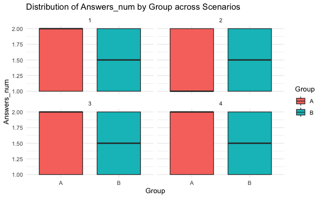

```r
Answers_plot
```

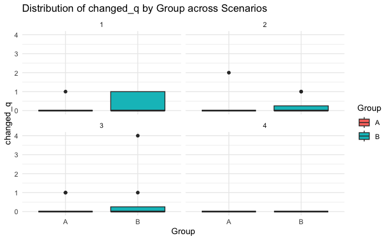

```r
changed_q_plot
```

```r
NA
NA
```

to check the overall effect without considering the sceanrio difference

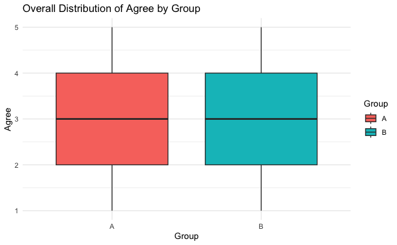

```r
# Load required library
library(ggplot2)

# Function to create boxplots for variables without considering scenarios
plot_variable_overall <- function(data, variable_name) {
  ggplot(data, aes(x = Group, y = .data[[variable_name]], fill = Group)) +
    geom_boxplot() +
    labs(
      title = paste("Overall Distribution of", variable_name, "by Group"),
      x = "Group",
      y = variable_name
    ) +
    theme_minimal()
}

# Create plots for each variable
agree_plot <- plot_variable_overall(data, "Agree")
credible_plot <- plot_variable_overall(data, "Credible")
confidence_plot <- plot_variable_overall(data, "Confidence")
changing_plot <- plot_variable_overall(data, "Changing")
Answers_plot <- plot_variable_overall(data, "Answers_num")
# Display plots
agree_plot
```

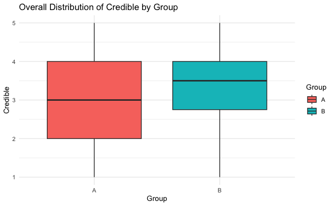

```r
credible_plot
```

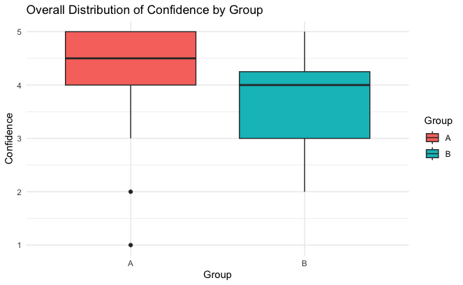

```r
confidence_plot
```

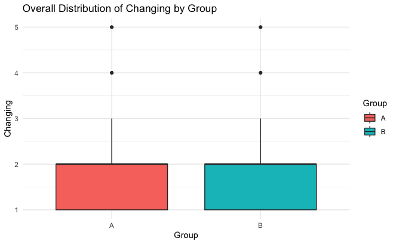

```r
changing_plot
```

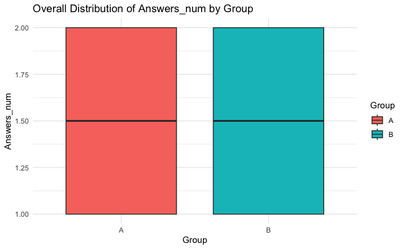

```r
Answers_plot
```

we perform shapiro wilk test to check the normality

```r
# Perform Shapiro-Wilk test for each variable
shapiro_agree <- shapiro.test(data$Agree)
shapiro_credible <- shapiro.test(data$Credible)
shapiro_confidence <- shapiro.test(data$Confidence)
shapiro_changing <- shapiro.test(data$Changing)
shapiro_Answers <- shapiro.test(data$Answers_num)
shapiro_changed <- shapiro.test(data$changed_q)
# Print results
print("Shapiro-Wilk Test for Agree:")
```

```
[1] "Shapiro-Wilk Test for Agree:"
```

```r
print(shapiro_agree)
```

```
    Shapiro-Wilk normality test

data:  data$Agree
W = 0.9148, p-value = 0.0001951
```

```r
print("Shapiro-Wilk Test for Credible:")
```

```
[1] "Shapiro-Wilk Test for Credible:"
```

```r
print(shapiro_credible)
```

```
    Shapiro-Wilk normality test

data:  data$Credible
W = 0.90822, p-value = 0.0001044
```

```r
print("Shapiro-Wilk Test for Confidence:")
```

```
[1] "Shapiro-Wilk Test for Confidence:"
```

```r
print(shapiro_confidence)
```

```
    Shapiro-Wilk normality test

data:  data$Confidence
W = 0.82264, p-value = 1.386e-07
```

```r
print("Shapiro-Wilk Test for Changing:")
```

```
[1] "Shapiro-Wilk Test for Changing:"
```

```r
print(shapiro_changing)
```

```
    Shapiro-Wilk normality test

data:  data$Changing
W = 0.73339, p-value = 8.545e-10
```

```r
print("Shapiro-Wilk Test for same/different answer:")
```

```
[1] "Shapiro-Wilk Test for same/different answer:"
```

```r
print(shapiro_Answers)
```

```
    Shapiro-Wilk normality test

data:  data$Answers_num
W = 0.63652, p-value = 1.07e-11
```

```r
print("Shapiro-Wilk Test for cahnged answer:")
```

```
[1] "Shapiro-Wilk Test for cahnged answer:"
```

```r
print(shapiro_changed)
```

```
    Shapiro-Wilk normality test

data:  data$changed_q
W = 0.40076, p-value = 3.58e-15
```

all of them smaller than 0.05, so they are not normal. we plot the q-q plot to see the normality in the dataset

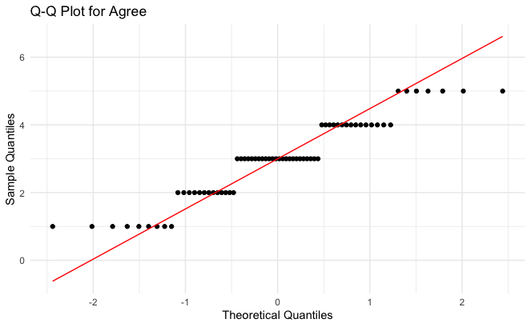

```r
# Load ggplot2 for visualization
library(ggplot2)

# Q-Q plot for Agree
ggplot(data, aes(sample = Agree)) +
  stat_qq() +
  stat_qq_line(color = "red") +
  labs(
    title = "Q-Q Plot for Agree",
    x = "Theoretical Quantiles",
    y = "Sample Quantiles"
  ) +
  theme_minimal()
```

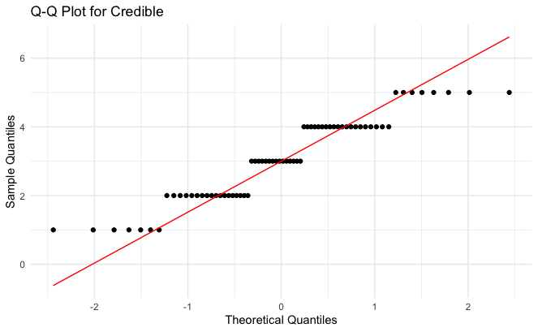

```r
# Q-Q plot for Credible
ggplot(data, aes(sample = Credible)) +
  stat_qq() +
  stat_qq_line(color = "red") +
  labs(
    title = "Q-Q Plot for Credible",
    x = "Theoretical Quantiles",
    y = "Sample Quantiles"
  ) +
  theme_minimal()
```

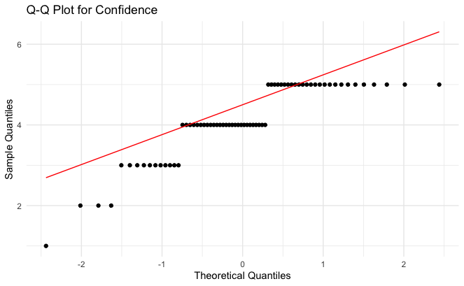

```r
# Q-Q plot for Confidence
ggplot(data, aes(sample = Confidence)) +
  stat_qq() +
  stat_qq_line(color = "red") +
  labs(
    title = "Q-Q Plot for Confidence",
    x = "Theoretical Quantiles",
    y = "Sample Quantiles"
  ) +
  theme_minimal()
```

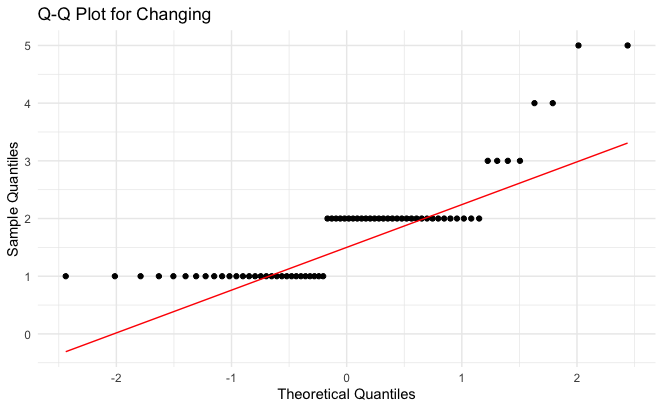

```r
# Q-Q plot for Changing
ggplot(data, aes(sample = Changing)) +
  stat_qq() +
  stat_qq_line(color = "red") +
  labs(
    title = "Q-Q Plot for Changing",
    x = "Theoretical Quantiles",
    y = "Sample Quantiles"
  ) +
  theme_minimal()
```

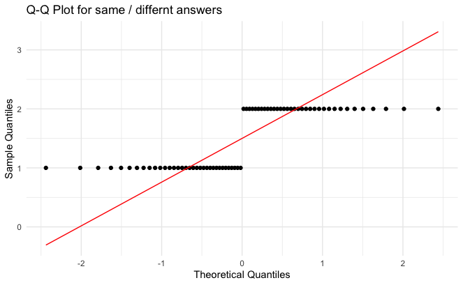

```r
# Q-Q plot for same or differnt
ggplot(data, aes(sample = Answers_num)) +
  stat_qq() +
  stat_qq_line(color = "red") +
  labs(
    title = "Q-Q Plot for same / differnt answers",
    x = "Theoretical Quantiles",
    y = "Sample Quantiles"
  ) +
  theme_minimal()
```

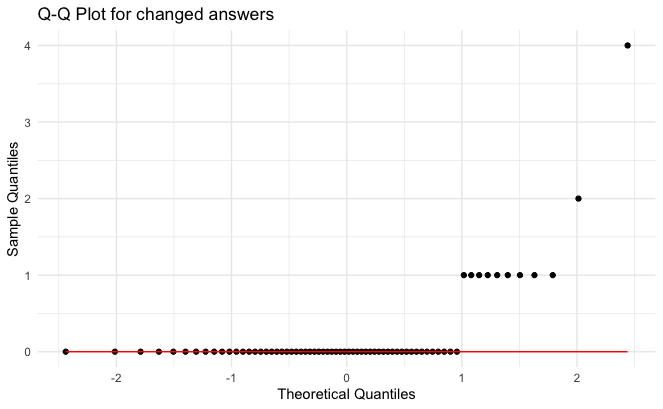

```r
# Q-Q plot for changed
ggplot(data, aes(sample = changed_q)) +
  stat_qq() +
  stat_qq_line(color = "red") +
  labs(
    title = "Q-Q Plot for changed answers",
    x = "Theoretical Quantiles",
    y = "Sample Quantiles"
  ) +
  theme_minimal()
```

data seem to have alot of variance. and its not normal.

we need to perform LLM

```r
install.packages("lme4")
install.packages("lmerTest")
```

for same an ddifferent answers

```r
library(lme4)
library(lmerTest)
# Fit the mixed model for Agree
model_agree <- lmer(Agree ~ Group + (1|Participant_ID), data = data)
model_agree_Answers  <- lmer(Agree ~ Group + (1|Participant_ID) + Answers_num, data = data)

# Fit the mixed model for Credible
model_credible <- lmer(Credible ~ Group + (1|Participant_ID), data = data)
model_credible_Answers  <- lmer(Credible ~ Group + (1|Participant_ID) + Answers_num, data = data)

# Fit the mixed model for Confidence
model_confidence <- lmer(Confidence ~ Group + (1|Participant_ID), data = data)
model_confidence_Answers  <- lmer(Confidence ~ Group + (1|Participant_ID) + Answers_num, data = data)

# Fit the mixed model for Changing
model_changing <- lmer(Changing ~ Group + (1|Participant_ID), data = data)
model_changing_Answers <- lmer(Changing ~ Group + (1|Participant_ID) + Answers_num, data = data)

# Fit the mixed model for Changed_q
model_Changed_q <- lmer(changed_q ~ Group + (1|Participant_ID), data = data)
```

```
boundary (singular) fit: see help('isSingular')
```

```r
model_Changed_q_Answers <- lmer(changed_q ~ Group + (1|Participant_ID) + Answers_num, data = data)
```

```
boundary (singular) fit: see help('isSingular')
```

```r
# Display the summary of each model with p-values
print(model_agree)
```

```
Linear mixed model fit by REML ['lmerModLmerTest']
Formula: Agree ~ Group + (1 | Participant_ID)
   Data: data
REML criterion at convergence: 214.6514
Random effects:
 Groups         Name        Std.Dev.
 Participant_ID (Intercept) 0.4407
 Residual                   1.1026
Number of obs: 68, groups:  Participant_ID, 17
Fixed Effects:
(Intercept)       GroupB
    2.94444      0.05556
```

```r
summary(model_agree)
```

```
Linear mixed model fit by REML. t-tests use Satterthwaite's method ['lmerModLmerTest']
Formula: Agree ~ Group + (1 | Participant_ID)
   Data: data

REML criterion at convergence: 214.7

Scaled residuals:
     Min       1Q   Median       3Q      Max
-1.90233 -0.66385  0.03074  0.75225  2.10988

Random effects:
 Groups         Name        Variance Std.Dev.
 Participant_ID (Intercept) 0.1942   0.4407
 Residual                   1.2157   1.1026
Number of obs: 68, groups:  Participant_ID, 17

Fixed effects:
            Estimate Std. Error       df t value Pr(>|t|)
(Intercept)  2.94444    0.23527 15.00000  12.515 2.43e-09 ***
GroupB       0.05556    0.34296 15.00000   0.162    0.873
---
Signif. codes:  0 ‘***’ 0.001 ‘**’ 0.01 ‘*’ 0.05 ‘.’ 0.1 ‘ ’ 1

Correlation of Fixed Effects:
       (Intr)
GroupB -0.686
```

```r
print(model_agree_Answers)
```

```
Linear mixed model fit by REML ['lmerModLmerTest']
Formula: Agree ~ Group + (1 | Participant_ID) + Answers_num
   Data: data
REML criterion at convergence: 201.5296
Random effects:
 Groups         Name        Std.Dev.
 Participant_ID (Intercept) 0.5133
 Residual                   0.9689
Number of obs: 68, groups:  Participant_ID, 17
Fixed Effects:
(Intercept)       GroupB  Answers_num
    4.35621      0.05556     -0.94118
```

```r
summary(model_agree_Answers)
```

```
Linear mixed model fit by REML. t-tests use Satterthwaite's method ['lmerModLmerTest']
Formula: Agree ~ Group + (1 | Participant_ID) + Answers_num
   Data: data

REML criterion at convergence: 201.5

Scaled residuals:
    Min      1Q  Median      3Q     Max
-2.1134 -0.4806  0.2128  0.6289  2.0148

Random effects:
 Groups         Name        Variance Std.Dev.
 Participant_ID (Intercept) 0.2634   0.5133
 Residual                   0.9388   0.9689
Number of obs: 68, groups:  Participant_ID, 17

Fixed effects:
            Estimate Std. Error       df t value Pr(>|t|)
(Intercept)  4.35621    0.42380 62.87776  10.279 4.33e-15 ***
GroupB       0.05556    0.34296 15.00000   0.162 0.873475
Answers_num -0.94118    0.23500 50.00000  -4.005 0.000206 ***
---
Signif. codes:  0 ‘***’ 0.001 ‘**’ 0.01 ‘*’ 0.05 ‘.’ 0.1 ‘ ’ 1

Correlation of Fixed Effects:
            (Intr) GroupB
GroupB      -0.381
Answers_num -0.832  0.000
```

```r
print(model_credible)
```

```
Linear mixed model fit by REML ['lmerModLmerTest']
Formula: Credible ~ Group + (1 | Participant_ID)
   Data: data
REML criterion at convergence: 217.0846
Random effects:
 Groups         Name        Std.Dev.
 Participant_ID (Intercept) 0.4607
 Residual                   1.1202
Number of obs: 68, groups:  Participant_ID, 17
Fixed Effects:
(Intercept)       GroupB
     2.8889       0.3611
```

```r
summary(model_credible)
```

```
Linear mixed model fit by REML. t-tests use Satterthwaite's method ['lmerModLmerTest']
Formula: Credible ~ Group + (1 | Participant_ID)
   Data: data

REML criterion at convergence: 217.1

Scaled residuals:
     Min       1Q   Median       3Q      Max
-1.91848 -0.65342  0.01414  0.75955  1.75448

Random effects:
 Groups         Name        Variance Std.Dev.
 Participant_ID (Intercept) 0.2122   0.4607
 Residual                   1.2549   1.1202
Number of obs: 68, groups:  Participant_ID, 17

Fixed effects:
            Estimate Std. Error      df t value Pr(>|t|)
(Intercept)   2.8889     0.2417 15.0000  11.951 4.57e-09 ***
GroupB        0.3611     0.3524 15.0000   1.025    0.322
---
Signif. codes:  0 ‘***’ 0.001 ‘**’ 0.01 ‘*’ 0.05 ‘.’ 0.1 ‘ ’ 1

Correlation of Fixed Effects:
       (Intr)
GroupB -0.686
```

```r
print(model_credible_Answers)
```

```
Linear mixed model fit by REML ['lmerModLmerTest']
Formula: Credible ~ Group + (1 | Participant_ID) + Answers_num
   Data: data
REML criterion at convergence: 213.9747
Random effects:
 Groups         Name        Std.Dev.
 Participant_ID (Intercept) 0.4793
 Residual                   1.0884
Number of obs: 68, groups:  Participant_ID, 17
Fixed Effects:
(Intercept)       GroupB  Answers_num
     3.6830       0.3611      -0.5294
```

```r
summary(model_credible_Answers)
```

```
Linear mixed model fit by REML. t-tests use Satterthwaite's method ['lmerModLmerTest']
Formula: Credible ~ Group + (1 | Participant_ID) + Answers_num
   Data: data

REML criterion at convergence: 214

Scaled residuals:
     Min       1Q   Median       3Q      Max
-2.12354 -0.70310  0.01351  0.63161  1.85100

Random effects:
 Groups         Name        Variance Std.Dev.
 Participant_ID (Intercept) 0.2297   0.4793
 Residual                   1.1847   1.0884
Number of obs: 68, groups:  Participant_ID, 17

Fixed effects:
            Estimate Std. Error      df t value Pr(>|t|)
(Intercept)   3.6830     0.4639 64.3982   7.939 3.98e-11 ***
GroupB        0.3611     0.3524 15.0000   1.025   0.3217
Answers_num  -0.5294     0.2640 50.0000  -2.005   0.0503 .
---
Signif. codes:  0 ‘***’ 0.001 ‘**’ 0.01 ‘*’ 0.05 ‘.’ 0.1 ‘ ’ 1

Correlation of Fixed Effects:
            (Intr) GroupB
GroupB      -0.357
Answers_num -0.854  0.000
```

```r
print(model_confidence)
```

```
Linear mixed model fit by REML ['lmerModLmerTest']
Formula: Confidence ~ Group + (1 | Participant_ID)
   Data: data
REML criterion at convergence: 167.8036
Random effects:
 Groups         Name        Std.Dev.
 Participant_ID (Intercept) 0.5987
 Residual                   0.7001
Number of obs: 68, groups:  Participant_ID, 17
Fixed Effects:
(Intercept)       GroupB
     4.3056      -0.4618
```

```r
summary(model_confidence)
```

```
Linear mixed model fit by REML. t-tests use Satterthwaite's method ['lmerModLmerTest']
Formula: Confidence ~ Group + (1 | Participant_ID)
   Data: data

REML criterion at convergence: 167.8

Scaled residuals:
    Min      1Q  Median      3Q     Max
-3.3317 -0.1112  0.1548  0.4208  2.3814

Random effects:
 Groups         Name        Variance Std.Dev.
 Participant_ID (Intercept) 0.3584   0.5987
 Residual                   0.4902   0.7001
Number of obs: 68, groups:  Participant_ID, 17

Fixed effects:
            Estimate Std. Error      df t value Pr(>|t|)
(Intercept)   4.3056     0.2312 15.0000   18.62 8.83e-12 ***
GroupB       -0.4618     0.3370 15.0000   -1.37    0.191
---
Signif. codes:  0 ‘***’ 0.001 ‘**’ 0.01 ‘*’ 0.05 ‘.’ 0.1 ‘ ’ 1

Correlation of Fixed Effects:
       (Intr)
GroupB -0.686
```

```r
print(model_confidence_Answers)
```

```
Linear mixed model fit by REML ['lmerModLmerTest']
Formula: Confidence ~ Group + (1 | Participant_ID) + Answers_num
   Data: data
REML criterion at convergence: 169.502
Random effects:
 Groups         Name        Std.Dev.
 Participant_ID (Intercept) 0.5966
 Residual                   0.7071
Number of obs: 68, groups:  Participant_ID, 17
Fixed Effects:
(Intercept)       GroupB  Answers_num
  4.306e+00   -4.618e-01   -7.572e-15
```